# Homework 4 Unsupervised Learning

```python
import numpy as np
import matplotlib.pyplot as plt
from skimage import data
import pandas as pd
from sklearn.model_selection import train_test_split
from sklearn.metrics import accuracy_score, precision_score, recall_score, confusion_matrix
```

## Exercise 1: Compute the SVD of a Matrix & Verify the Reconstruction

1. Construct any non-square matrix $A \in \mathbb{R}^{m \times n}$ (e.g. $m=10$, $n=6$) with random or structured entries.
2. Compute its SVD:

   $$ A = U\Sigma V^T. $$
3. Verify numerically that:

   $$ A \approx U\Sigma V^T, \qquad \|A - U\Sigma V^T\|_F \approx 0. $$
4. Print and plot the singular values $\sigma_1,\dots,\sigma_{\min(m,n)}$.
5. Comment on why singular values appear in descending order, why small singular values correspond to “less important” directions, and why floating-point arithmetic makes exact zeros rare.

```python
# Set random seed for reproducibility
np.random.seed(42)

# --- 1. Construct Matrix ---
# Create a random matrix A of size 10x6
m, n = 10, 6
A = np.random.randn(m, n)

# --- 2. Compute SVD ---
# np.linalg.svd returns U, the array of singular values (S), and V transposed (Vt)
# full_matrices=True means U is (m, m) and Vt is (n, n)
U, S_vals, Vt = np.linalg.svd(A, full_matrices=True)

print(f"Shape of U: {U.shape}")
print(f"Shape of singular values: {S_vals.shape}")
print(f"Shape of V^T: {Vt.shape}")
```

```
Shape of U: (10, 10)
Shape of singular values: (6,)
Shape of V^T: (6, 6)
```

```python
# --- 3. Verify Reconstruction ---
# Create the diagonal matrix Sigma of size (m, n)
Sigma = np.zeros((m, n))
min_dim = min(m, n)

# Populate the diagonal with singular values
Sigma[:min_dim, :min_dim] = np.diag(S_vals)

# Reconstruct A using the formula A = U * Sigma * Vt
A_reconstructed = U @ Sigma @ Vt

# Compute the Frobenius norm of the difference matrix (residual)
diff_norm = np.linalg.norm(A - A_reconstructed, 'fro')

print(f"Reconstruction Error (Frobenius Norm): {diff_norm:.2e}")
```

```
Reconstruction Error (Frobenius Norm): 5.27e-15
```

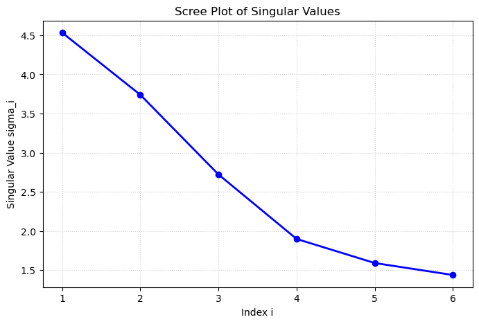

```
Singular Values: [4.53270928 3.73907164 2.72173241 1.89806806 1.59069575 1.43784506]
```

```python
# --- 4. Plot Singular Values ---
plt.figure(figsize=(8, 5))
plt.plot(range(1, len(S_vals) + 1), S_vals, 'o-', linewidth=2, color='blue')
plt.title('Scree Plot of Singular Values')
plt.xlabel('Index i')
plt.ylabel('Singular Value sigma_i')
plt.grid(True, linestyle=':', alpha=0.6)
plt.show()

print("Singular Values:", S_vals)
```

```python
'''
Tienes que crear una matriz aleatoria $A$, descomponerla usando la función np.linalg.svd en sus tres componentes
($U, \Sigma, V^T$) y luego volver a multiplicarlas para comprobar que recuperas la matriz original.
También debes graficar los valores singulares ($\sigma_i$) para ver cómo decaen.


Pregunta: ¿Por qué los valores singulares aparecen en orden descendente?
Respuesta: "Es una convención matemática estándar. Los algoritmos de SVD siempre devuelven los valores singulares
ordenados de mayor a menor ($\sigma_1 \ge \sigma_2 \ge \dots \ge 0$).


Pregunta: ¿Por qué los valores pequeños corresponden a direcciones 'menos importantes'?
Respuesta: "Geométricamente, la SVD convierte una esfera en un elipsoide. Los valores singulares son las longitudes
de los semiejes de ese elipsoide.
Un $\sigma_i$ muy grande significa que los datos se estiran mucho en esa dirección (mucha 'energía' o información).
Un $\sigma_i$ cercano a 0 significa que la matriz aplana los datos en esa dirección. En ciencia de datos, interpretamos
estas direcciones pequeñas como ruido o redundancia que podemos descartar."


Pregunta: ¿Por qué es raro obtener ceros exactos en aritmética de punto flotante?
Respuesta: "Teóricamente, si una matriz no tiene rango completo, algunos valores singulares deberían ser exactamente 0.
Sin embargo, debido a la precisión finita de las computadoras (errores de redondeo o machine epsilon),
estos ceros aparecen como números extremadamente pequeños (ej. $10^{-16}$). Numéricamente se consideran cero,
pero no lo son exactamente."
'''
```

## Exercise 2: Best Rank-$k$ Approximation

1. Implement a function:

   $$ A_k = \sum_{i=1}^k \sigma_i u_i v_i^T. $$
2. For several values of $k$, compute:

   $$ E(k) = \|A - A_k\|_F. $$
3. Plot the approximation error $E(k)$ vs $k$.
4. Explain why SVD gives the *optimal* rank-$k$ approximation.

```python
# --- 1. Function Implementation ---

def get_rank_k_approximation(U, S, Vt, k):
    # Slice the matrices to keep only the first k components
    U_k = U[:, :k]
    S_k = np.diag(S[:k])
    Vt_k = Vt[:k, :]

    # Reconstruct the approximation: Ak = Uk * Sk * Vtk
    return U_k @ S_k @ Vt_k

# --- 2. Error Computation Loop ---

# Generate a slightly larger random matrix for this experiment
m, n = 20, 15
np.random.seed(42)
A = np.random.randn(m, n)

# Compute SVD (full_matrices=False is more efficient for non-square matrices)
U, S, Vt = np.linalg.svd(A, full_matrices=False)

max_rank = min(m, n)
errors = []
ks = range(1, max_rank + 1)

for k in ks:
    # Compute rank-k approximation
    A_k = get_rank_k_approximation(U, S, Vt, k)

    # Calculate Frobenius norm of the residual (A - Ak)
    error = np.linalg.norm(A - A_k, 'fro')
    errors.append(error)
```

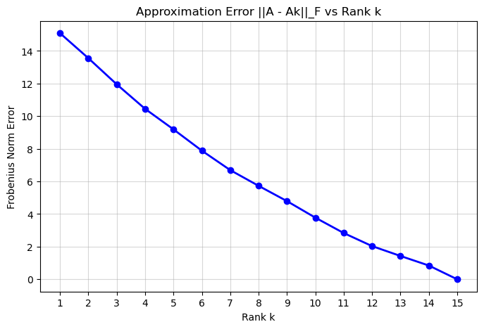

```python
# --- 3. Plotting ---
plt.figure(figsize=(8, 5))
plt.plot(ks, errors, 'o-', color='blue', linewidth=2, label='Approximation Error')
plt.title('Approximation Error ||A - Ak||_F vs Rank k')
plt.xlabel('Rank k')
plt.ylabel('Frobenius Norm Error')
plt.xticks(ks)
plt.grid(True, alpha=0.5)
plt.show()
```

```python
'''
Aquí implementas la fórmula de truncamiento:$$A_k = \sum_{i=1}^k \sigma_i u_i v_i^T$$En lugar de sumar todos los componentes,
solo sumas los primeros $k$. Esto crea una versión "simplificada" de la matriz original.Calculas el error $\|A - A_k\|_F$
(Norma de Frobenius) y ves cómo disminuye al aumentar $k$.


Pregunta: Explica por qué la SVD da la óptima aproximación de rango k.
Respuesta: "Esto se debe al Teorema de Eckart-Young-Mirsky.
Este teorema demuestra matemáticamente que si queremos aproximar una matriz $A$ con otra matriz $B$ que tenga un rango
menor $k$, la mejor matriz $B$ posible (la que minimiza el error cuadrático) es la que se obtiene truncando la SVD a los
primeros $k$ términos.
Ninguna otra descomposición puede darnos un error menor para un rango fijo $k$."
'''
```

## Exercise 3: Image Compression with SVD

Using the `cameraman` image (as in the notes):

1. Load the image as a matrix $X \in \mathbb{R}^{512\times512}$.
2. Compute its SVD:

   $$ X = U\Sigma V^T. $$
3. For $k \in \{5, 20, 50, 100, 200\}$:
   - Compute the rank-$k$ approximation $X_k$,
   - Plot each reconstructed image,
   - Compute the compression factor:

     $$ c_k = 1 - \frac{k(m+n+1)}{mn}. $$
   - Plot reconstruction error vs $k$,
   - Plot compression factor vs $k$.
4. Comment on:
   - How visual quality improves with $k$,
   - Why most of the “energy” is contained in the first singular values,
   - The trade-off between compression and fidelity,
   - The connection between SVD and optimal low-rank approximation.

```
SVD Computed. Singular values count: 512
```

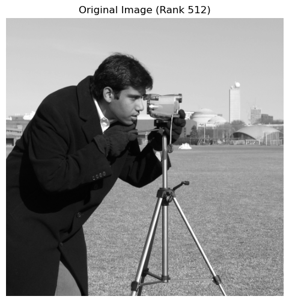

```python
# --- 1. Load Data ---
# Load the 'camera' image (512x512 grayscale)
X = data.camera().astype(float)
m, n = X.shape

# --- 2. Compute SVD ---
U, S, Vt = np.linalg.svd(X, full_matrices=False)

print(f"SVD Computed. Singular values count: {len(S)}")

# Visualize Original
plt.figure(figsize=(6, 6))
plt.imshow(X, cmap='gray')
plt.title("Original Image (Rank 512)")
plt.axis('off')
plt.show()
```

[figure not shown]

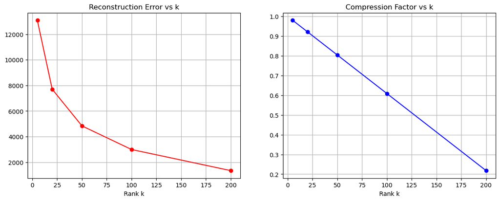

```python
# --- 3. Compression Loop ---
k_values = [5, 20, 50, 100, 200]
errors = []
compression_factors = []

fig, axes = plt.subplots(1, len(k_values), figsize=(20, 5))

for i, k in enumerate(k_values):
    # Construct Rank-k Approximation
    # Broadcasting: S[:k] scales the columns of U[:, :k]
    # Equivalent to U[:, :k] @ np.diag(S[:k]) @ Vt[:k, :]
    X_k = (U[:, :k] * S[:k]) @ Vt[:k, :]

    # Compute Reconstruction Error
    error = np.linalg.norm(X - X_k, 'fro')
    errors.append(error)

    # Calculate Compression Factor
    # Number of elements stored vs total elements in original image
    params_stored = k * (m + n + 1)
    total_params = m * n
    c_k = 1 - (params_stored / total_params)
    compression_factors.append(c_k)

    # Visualize
    axes[i].imshow(X_k, cmap='gray')
    axes[i].set_title(f"k={k}\nComp: {c_k:.1%}")
    axes[i].axis('off')

plt.tight_layout()
plt.show()

# --- Plot Metrics ---
fig, (ax1, ax2) = plt.subplots(1, 2, figsize=(14, 5))

# Error vs k
ax1.plot(k_values, errors, 'r-o')
ax1.set_title("Reconstruction Error vs k")
ax1.set_xlabel("Rank k")
ax1.grid(True)

# Compression Factor vs k
ax2.plot(k_values, compression_factors, 'b-o')
ax2.set_title("Compression Factor vs k")
ax2.set_xlabel("Rank k")
ax2.grid(True)

plt.show()
```

```python
'''
Aplicas lo anterior a una imagen real (ej. "Cameraman"). Una imagen en escala de grises es simplemente una matriz de números
(brillo de píxeles).Calculas la SVD de la imagen.Reconstruyes la imagen usando solo $k=5, 20, 50$ componentes.
Observas cómo con muy poca información ($k$ bajo) ya se distingue la figura.


Pregunta: ¿Por qué la mayor parte de la "energía" está en los primeros valores singulares?
Respuesta: "Porque las imágenes reales no son ruido aleatorio; tienen estructura y correlación.Los píxeles vecinos suelen tener
colores similares (el cielo es azul, el traje es negro).
Esta alta correlación significa que hay mucha redundancia. La SVD captura las estructuras principales
(formas, gradientes de luz) en los primeros modos ($\sigma$ grandes), dejando solo los detalles finos y el ruido para
los últimos."


Pregunta: Comenta el compromiso (trade-off) entre compresión y fidelidad.
Respuesta:
$k$ bajo (ej. 5): Alta compresión (ocupamos muy poco espacio), pero baja fidelidad (la imagen se ve borrosa o fantasmal).
$k$ alto (ej. 100): Baja compresión, pero la imagen es casi idéntica a la original.
El punto dulce: En las gráficas verás un "codo". A partir de cierto $k$, añadir más componentes apenas mejora la calidad
visual pero sigue costando memoria.
'''
```

## Exercise 5: PCA + Clustering on a Real Dataset

Use the MNIST Kaggle dataset: https://www.kaggle.com/datasets/animatronbot/mnist-digit-recognizer.

To reduce computational burden, **filter only digits 3 and 4** exactly as in the teaching notes.

Do as follows:

1. Load the CSV file into memory (you may use NumPy or pandas).
2. Split into training and test sets.
3. Center the training data:

   $$ X_{c,\text{train}} = X_{\text{train}} - c(X_{\text{train}}). $$
4. Compute the reduced SVD of the centered training data.
5. Choose $k=2$ principal components.
6. Project:
   - $Z_{\text{train}} = X_{c,\text{train}} V_2$,
   - $Z_{\text{test}} = X_{c,\text{test}} V_2$.
7. Plot:
   - Scatterplot of $Z_{\text{train}}$ colored by labels (3 vs 4),
   - Scatterplot of $Z_{\text{test}}$ overlaid in the same plot.
8. Repeat with digits 5 vs 8, or 1 vs 7 and discuss on the different results.
9. Finally, try $k=3$ and use a 3D scatterplot.

```python
def run_pca_pipeline(digits_to_keep, k=2, plot_3d=False):
    # --- 1. Load Data ---
    df = pd.read_csv('train.csv')
    X_full = df.iloc[:, 1:].values
    y_full = df.iloc[:, 0].values

    # --- 2. Filter Digits ---
    mask = np.isin(y_full, digits_to_keep)
    X = X_full[mask]
    y = y_full[mask]

    # Split
    X_train, X_test, y_train, y_test = train_test_split(X, y, test_size=0.3, random_state=42)

    # --- 3. Center Data ---
    # We compute mean on TRAIN only and apply to both
    mean_vec = np.mean(X_train, axis=0)
    X_c_train = X_train - mean_vec
    X_c_test = X_test - mean_vec

    # --- 4. Compute Reduced SVD ---
    # SVD of X_c_train = U * S * Vt
    # We only need Vt to get the principal components (eigenvectors of covariance)
    U, S, Vt = np.linalg.svd(X_c_train, full_matrices=False)

    # --- 5. Choose k Components ---
    # The rows of Vt are the principal components.
    # We transpose the first k rows to get the projection matrix V_k (Dim x k)
    V_k = Vt[:k, :].T

    # --- 6. Project ---
    Z_train = X_c_train @ V_k
    Z_test = X_c_test @ V_k

    # --- 7. Plotting ---
    colors = ['blue', 'red']
    markers = ['o', 's']

    if plot_3d:
        fig = plt.figure(figsize=(10, 8))
        ax = fig.add_subplot(111, projection='3d')

        for i, digit in enumerate(digits_to_keep):
            # Train points
            mask_tr = (y_train == digit)
            ax.scatter(Z_train[mask_tr, 0], Z_train[mask_tr, 1], Z_train[mask_tr, 2],
                       label=f'Train {digit}', alpha=0.3, c=colors[i], marker=markers[0])
            # Test points
            mask_te = (y_test == digit)
            ax.scatter(Z_test[mask_te, 0], Z_test[mask_te, 1], Z_test[mask_te, 2],
                       label=f'Test {digit}', c=colors[i], marker=markers[1], edgecolors='k')

        ax.set_title(f"3D PCA: Digits {digits_to_keep}")
        ax.set_xlabel("PC 1")
        ax.set_ylabel("PC 2")
        ax.set_zlabel("PC 3")
        ax.legend()
        plt.show()

    else:
        plt.figure(figsize=(10, 6))

        for i, digit in enumerate(digits_to_keep):
            # Train points
            mask_tr = (y_train == digit)
            plt.scatter(Z_train[mask_tr, 0], Z_train[mask_tr, 1],
                        label=f'Train {digit}', alpha=0.2, c=colors[i], marker=markers[0])

            # Test points
            mask_te = (y_test == digit)
            plt.scatter(Z_test[mask_te, 0], Z_test[mask_te, 1],
                        label=f'Test {digit}', c=colors[i], marker=markers[1], edgecolors='k')

        plt.title(f"2D PCA: Digits {digits_to_keep}")
        plt.xlabel("Principal Component 1")
        plt.ylabel("Principal Component 2")
        plt.legend()
        plt.grid(True, alpha=0.3)
        plt.show()
```

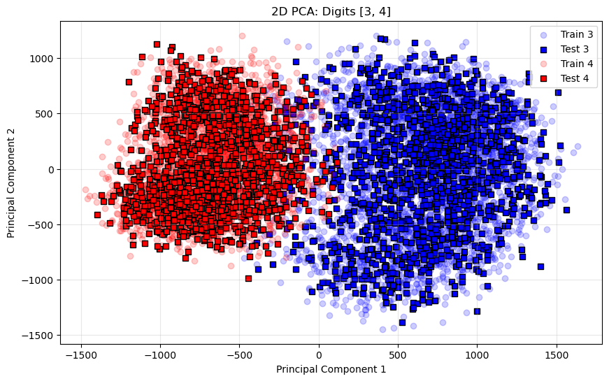

```python
# Run for 3 vs 4
run_pca_pipeline([3, 4], k=2)
```

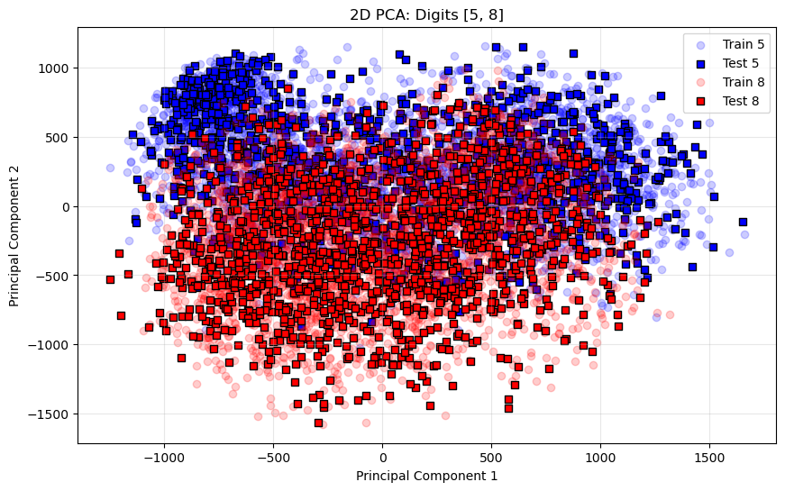

```python
# Run for 5 vs 8
run_pca_pipeline([5, 8], k=2)
```

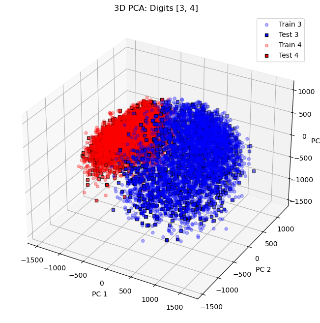

```python
# Run for 3 vs 4 in 3D
run_pca_pipeline([3, 4], k=3, plot_3d=True)
```

```python
'''
Trabajas con imágenes de 28x28 píxeles (784 dimensiones). Como los humanos no podemos ver en 784 dimensiones,
usas PCA (Análisis de Componentes Principales) para aplastar esas imágenes a solo 2 o 3 dimensiones ($k=2, k=3$)
manteniendo la mayor información posible.
'''
```

## Exercise 6: Classification After PCA: Linear Classifier and Centroid Classifier

In this exercise, you will build two simple classifiers **after projecting the data with PCA**:

1. **A linear classifier on 2D PCA features**,
2. **A PCA-centroid classifier** that assigns each test point to the closest class centroid in the reduced space.

You will perform all experiments on the same Kaggle dataset used previously: https://www.kaggle.com/datasets/animatronbot/mnist-digit-recognizer, filtering only digits 3 and 4, as you did in the previosu exercise.

The aim of this exercise is to connect dimensionality reduction with classification and illustrates how PCA can be used not only for visualization, but also as a preprocessing tool for machine learning pipelines.

### Step 1: PCA Projection

1. Load and split digits {3,4} into `train` and `test`.
2. Center the training data:

   $$ X_{c,\text{train}} = X_{\text{train}} - c(X_{\text{train}}). $$
3. Compute the reduced SVD:

   $$ X_{c,\text{train}} = U \Sigma V^T. $$
4. Take the first two principal directions:

   $$ P = V_2 \in \mathbb{R}^{d \times 2}. $$
5. Project:

   $$ Z_{\text{train}} = X_{c,\text{train}} P, \qquad Z_{\text{test}} = (X_{\text{test}} - c(X_{\text{train}}))\, P. $$

You will now use these 2D representations $Z_{\text{train}}$ and $Z_{\text{test}}$ for classification.

### Step 2: Fit a linear classifier

1. Use the logistic regression model:

   $$ f_{\Theta}(z) = \sigma(\Theta^T z), \qquad z \in \mathbb{R}^2, $$

   with sigmoid and binary cross-entropy loss, and train the model using SGD.
2. Once trained:
   1. Plot the PCA-reduced training data in 2D,
   2. Plot the decision boundary defined by:

      $$ \Theta^T z = 0 \quad \Rightarrow \quad \text{boundary line}. $$
3. Compute, on the test set:
   - Accuracy,
   - Precision and Recall,
   - Confusion matrix.

### Step 3: PCA-Centroid Classifier (Nearest-Centroid in PCA Space)

This classifier does **not** use a linear model. It relies purely on geometry in the reduced PCA space.

1. For each class $c\in\{3,4\}$, compute the centroid in PCA space:

   $$ \mu_c = \frac{1}{|\mathcal{D}_c|}\sum_{z_i \in \mathcal{D}_c} z_i. $$

   Plot both centroids $\mu_3$ and $\mu_4$ in the PCA plane.
2. Given a test sample $x\in\mathbb{R}^d$:
   1. Project it:

      $$ z = (x - c(X_{\text{train}}))\, P. $$
   2. Compute distances:

      $$ d_3 = \|z - \mu_3\|_2,\qquad d_4 = \|z - \mu_4\|_2. $$
   3. Assign:

      $$ \hat y = \arg\min_{c\in\{3,4\}} d_c. $$

   This is the **nearest-centroid classifier in PCA space**.
3. Compute, on the test set:
   - Accuracy,
   - Precision and Recall,
   - Confusion matrix.

   Plot the test points with colors given by classification results.

### Step 4: Compare accuracy and error patterns

1. Compare linear classifier on PCA features vs centroid classifier in PCA space.
2. On the PCA scatterplot, plot:
   - the linear boundary,
   - the two centroids,
   - misclassified test samples highlighted in red.
3. Repeat by changing the digits in $\{ (1,7), (5,8), (2,3) \}$ and observe how class similarity influences:
   - the cluster shape,
   - centroid separation,
   - decision boundaries.

```python
# --- Helper: Logistic Regression Training ---
def sigmoid(z):
    return np.where(z >= 0, 1/(1+np.exp(-z)), np.exp(z)/(1+np.exp(z)))


def train_logistic(X, y, eta=0.1, n_iters=1000):
    # Trains a Logistic Regression model using Gradient Descent.

    m = X.shape[0]
    # Add bias column (ones)
    X_b = np.c_[np.ones((m, 1)), X]
    theta = np.zeros((X_b.shape[1], 1))

    for _ in range(n_iters):
        # Forward pass
        h = sigmoid(X_b @ theta)
        # Gradient computation
        grad = (1/m) * X_b.T @ (h - y)
        # Update
        theta -= eta * grad
    return theta


# --- Master Pipeline Function ---
def run_pca_classification(digits_pair):
    d0, d1 = digits_pair
    print(f"PCA + Classification for digits {d0} vs {d1}")

    # --- 1. Load and Filter Data ---
    df = pd.read_csv("train.csv")
    X_full = df.iloc[:, 1:].values
    y_full = df.iloc[:, 0].values

    # Keep only the two requested digits
    mask = np.isin(y_full, digits_pair)
    X = X_full[mask]
    y = y_full[mask]

    # Create binary labels for logistic regression (0 for d0, 1 for d1)
    y_bin = (y == d1).astype(int).reshape(-1, 1)

    # --- 2. Split Data ---
    X_train, X_test, y_train, y_test = train_test_split(
        X, y_bin, test_size=0.3, random_state=42
    )

    # --- 3. PCA Projection ---
    # Compute mean of training data
    mean_vec = np.mean(X_train, axis=0)
    # Center both training and test data using TRAINING mean
    X_c_train = X_train - mean_vec
    X_c_test = X_test - mean_vec

    # Compute SVD on training data
    U, S, Vt = np.linalg.svd(X_c_train, full_matrices=False)

    # Select top 2 principal components (first 2 rows of Vt)
    P = Vt[:2, :].T

    # Project data onto the 2D subspace
    Z_train = X_c_train @ P
    Z_test = X_c_test @ P

    # METHOD A: Linear Classifier (Logistic Regression)
    theta = train_logistic(Z_train, y_train)

    # Predict on test set
    Z_test_b = np.c_[np.ones((len(Z_test), 1)), Z_test]
    probs = sigmoid(Z_test_b @ theta)
    preds_lr = (probs >= 0.5).astype(int)

    print("\n--- Linear Classifier (Logistic Regression on PCA space) ---")
    print(f"Accuracy:  {accuracy_score(y_test, preds_lr):.4f}")
    print(f"Precision: {precision_score(y_test, preds_lr):.4f}")
    print(f"Recall:    {recall_score(y_test, preds_lr):.4f}")
    print("Confusion Matrix:")
    print(confusion_matrix(y_test, preds_lr))

    # METHOD B: PCA-Centroid Classifier
    # Compute centroids in the reduced 2D space for each class
    mask_0 = (y_train.flatten() == 0)
    mask_1 = (y_train.flatten() == 1)

    mu_0 = np.mean(Z_train[mask_0], axis=0)
    mu_1 = np.mean(Z_train[mask_1], axis=0)

    # Compute Euclidean distances from test points to centroids
    dist_0 = np.linalg.norm(Z_test - mu_0, axis=1)
    dist_1 = np.linalg.norm(Z_test - mu_1, axis=1)

    # Assign class based on the minimum distance
    preds_centroid = (dist_1 < dist_0).astype(int).reshape(-1, 1)

    print("\n--- PCA-Centroid Classifier ---")
    print(f"Accuracy:  {accuracy_score(y_test, preds_centroid):.4f}")
    print(f"Precision: {precision_score(y_test, preds_centroid):.4f}")
    print(f"Recall:    {recall_score(y_test, preds_centroid):.4f}")
    print("Confusion Matrix:")
    print(confusion_matrix(y_test, preds_centroid))

    # --- 4. Plotting ---
    plt.figure(figsize=(10, 6))

    # Plot Test Points
    plt.scatter(Z_test[y_test.flatten()==0, 0],
                Z_test[y_test.flatten()==0, 1],
                c='red', alpha=0.3, label=f'Digit {d0}')

    plt.scatter(Z_test[y_test.flatten()==1, 0],
                Z_test[y_test.flatten()==1, 1],
                c='blue', alpha=0.3, label=f'Digit {d1}')

    # Plot Linear Boundary (where theta0 + theta1*z1 + theta2*z2 = 0)
    x_vals = np.array([Z_test[:,0].min(), Z_test[:,0].max()])
    y_vals = -(theta[0] + theta[1]*x_vals) / theta[2]
    plt.plot(x_vals, y_vals, 'k-', linewidth=2, label='Linear Boundary')

    # Centroids
    plt.plot(mu_0[0], mu_0[1], 'yx', markersize=12, markeredgewidth=3, label=f'Centroid {d0}')
    plt.plot(mu_1[0], mu_1[1], 'cx', markersize=12, markeredgewidth=3, label=f'Centroid {d1}')

    # Misclassified points (Linear)
    misclassified = (preds_lr != y_test).flatten()
    if np.any(misclassified):
        plt.scatter(Z_test[misclassified, 0],
                    Z_test[misclassified, 1],
                    facecolors='none', edgecolors='k',
                    s=100, label='Misclassified (Linear)')

    plt.title(f"PCA Classification: {d0} vs {d1}")
    plt.xlabel("PC 1")
    plt.ylabel("PC 2")
    plt.legend()
    plt.grid(True, alpha=0.3)
    plt.show()
```

```
PCA + Classification for digits 3 vs 4
```

```
--- Linear Classifier (Logistic Regression on PCA space) ---
Accuracy:  0.9699
Precision: 0.9468
Recall:    0.9925
Confusion Matrix:
[[1258   67]
 [   9 1193]]

--- PCA-Centroid Classifier ---
Accuracy:  0.9715
Precision: 0.9513
Recall:    0.9908
Confusion Matrix:
[[1264   61]
 [  11 1191]]
```

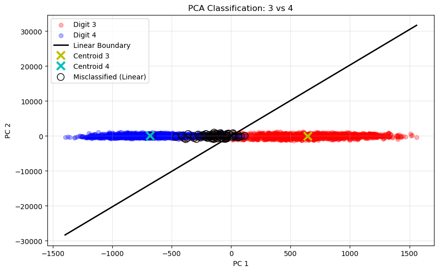

```python
# Run for 3 vs 4
run_pca_classification((3, 4))
```

```
PCA + Classification for digits 1 vs 7
```

```
--- Linear Classifier (Logistic Regression on PCA space) ---
Accuracy:  0.9685
Precision: 0.9915
Recall:    0.9451
Confusion Matrix:
[[1350   11]
 [  75 1290]]

--- PCA-Centroid Classifier ---
Accuracy:  0.9578
Precision: 0.9952
Recall:    0.9201
Confusion Matrix:
[[1355    6]
 [ 109 1256]]
```

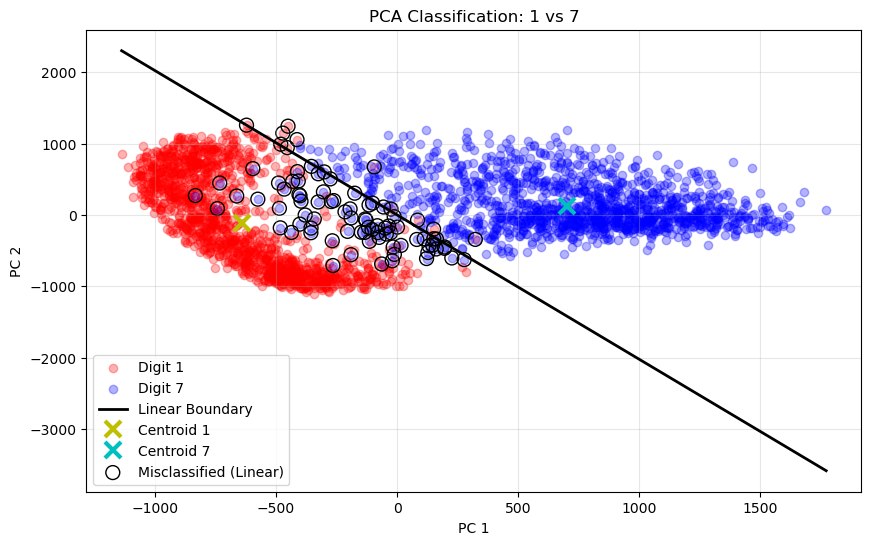

```python
# Run for 1 vs 7
run_pca_classification((1, 7))
```

```
PCA + Classification for digits 5 vs 8
```

```
--- Linear Classifier (Logistic Regression on PCA space) ---
Accuracy:  0.6849
Precision: 0.6835
Recall:    0.7158
Confusion Matrix:
[[751 400]
 [343 864]]

--- PCA-Centroid Classifier ---
Accuracy:  0.7642
Precision: 0.7878
Recall:    0.7382
Confusion Matrix:
[[911 240]
 [316 891]]
```

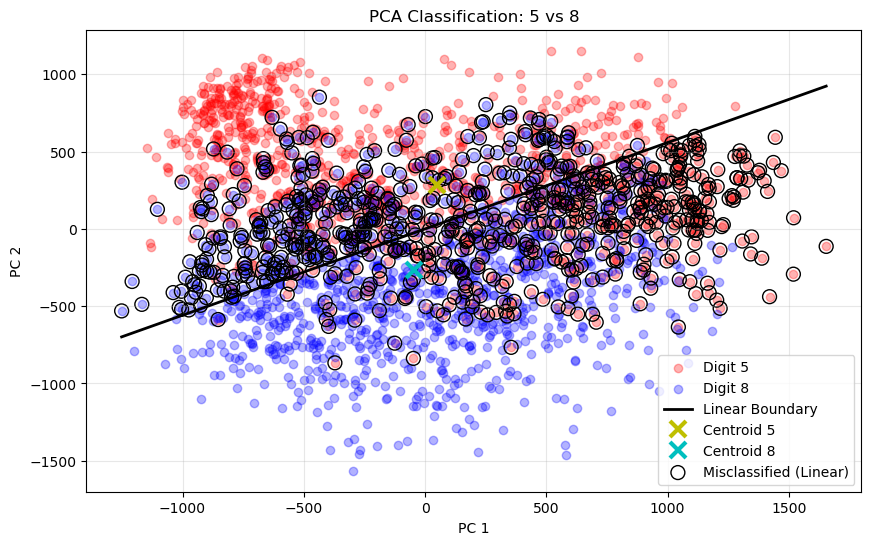

```python
# Run for 5 vs 8
run_pca_classification((5, 8))
```

```
PCA + Classification for digits 2 vs 3
```

```
--- Linear Classifier (Logistic Regression on PCA space) ---
Accuracy:  0.9125
Precision: 0.9138
Recall:    0.9138
Confusion Matrix:
[[1147  112]
 [ 112 1188]]

--- PCA-Centroid Classifier ---
Accuracy:  0.9078
Precision: 0.9030
Recall:    0.9169
Confusion Matrix:
[[1131  128]
 [ 108 1192]]
```

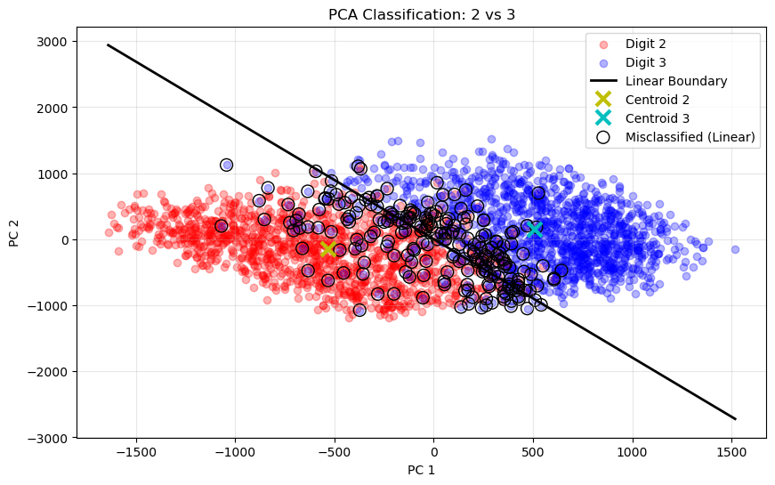

```python
# Run for 2 vs 3
run_pca_classification((2, 3))
```

```python
'''
Tomas las imágenes de 784 píxeles, las comprimes a solo 2 coordenadas (PC1, PC2) usando PCA, y luego intentas clasificar si son
un "3" o un "4" usando solo esos 2 números. Comparas dos métodos:

Clasificador Lineal (Regresión Logística): Intenta dibujar una línea recta que separe los puntos rojos de los azules.

Clasificador de Centroides (Nearest Centroid): Calcula el punto promedio ("prototipo") de los 3s y el promedio de los 4s.
Asigna cada punto nuevo al centroide que tenga más cerca.
'''
```